# 385 Midterm

Charles Franklin

#### This pair of datasets is comprised of sales data gathered from a bookstore. The “register” table contains information gathered at the register, such as what was bought, for how much, and some details about the customer. The other table, “sales,” has the sums of the monthly sales categorized by the type of inventory item (ie. food, books, apparel, etc.).

#### Before we can get into the data, we need to prepare our working environment by installing the “tidyverse” package. This contains all of the libraries of functions and tools we need to work with the raw data and change it around or pull what we need to out of it, as well as getting some of the useful stuff into graphs for visualizing it.

#### Once we get that loaded, we will get those specific libraries loaded that we’re going to use later on.

```r
suppressMessages(install.packages("tidyverse", repos="http://cran.us.r-project.org"))
suppressMessages(library("tidyverse"))
suppressMessages(library("dplyr"))
suppressMessages(library("tidyr"))
```

#### Next we will load the csv files into variables so that the data is accessible.

#### We should also take a look at a what the tables look like with the “head” function.

```r
suppressMessages(register <- read_csv("register.csv"))
head(register)
```

| purchase | item | charge | price | is the customer a student/faculty/staff (0) or unaffiliated (1) | customer id | receipt | contact preference | newsletter | sales | preferred customer discount |
| --- | --- | --- | --- | --- | --- | --- | --- | --- | --- | --- |
| 1 | 396941 | cost | 50.00 | 0 | 4 | FALSE | email | TRUE | TRUE | TRUE |
| 1 | 396941 | tax | 0.50 | 0 | 4 | FALSE | email | TRUE | TRUE | TRUE |
| 2 | 528028 | cost | 20.99 | 1 | -- | TRUE | -- | -- | -- | -- |
| 2 | 528028 | tax | 0.30 | 1 | -- | TRUE | -- | -- | -- | -- |
| 2 | 396941 | cost | 50.00 | 1 | -- | TRUE | -- | -- | -- | -- |
| 2 | 396941 | tax | 0.50 | 1 | -- | TRUE | -- | -- | -- | -- |

```r
suppressMessages(sales <- read_csv("sales.csv"))
head(sales)
```

| category of inventory goods | 1-2018 | 2-2018 | 3-2018 | 4-2018 | 5-2018 | 6-2018 | 7-2018 | 8-2018 | 9-2018 | 10-2018 | 11-2018 | 12-2018 | 1-2019 | 2-2019 | 3-2019 | 4-2019 | 5-2019 | 6-2019 | 7-2019 | 8-2019 | 9-2019 | 10-2019 |
| --- | --- | --- | --- | --- | --- | --- | --- | --- | --- | --- | --- | --- | --- | --- | --- | --- | --- | --- | --- | --- | --- | --- |
| food | 10.6 | 11.01 | 15.5 | 16.6 | 12.8 | 4.13 | 2.8 | 5 | 8.25 | 9.2 | 10.35 | 6.4 | 10.8 | 12.3 | 14.9 | 16 | 15 | 5.3 | 4.02 | 3.14 | 8.5 | 5.6 |
| drinks | 8.0 | 9.00 | 13.0 | 19.0 | 24.0 | 7.00 | 6.0 | 10 | 12.00 | 12.0 | 8.00 | 4.0 | 9.0 | 9.0 | 12.0 | 19 | 25 | 10.0 | 8.00 | 9.00 | 11.0 | 8.0 |
| textbooks | 105.0 | 135.00 | 20.0 | 11.0 | 21.0 | 7.00 | 3.0 | 250 | 100.00 | 15.0 | 13.00 | 5.0 | 111.0 | 129.0 | 13.0 | 10 | 10 | 8.0 | 4.00 | 239.00 | 99.0 | 21.0 |
| supplies | 8.0 | 13.00 | 4.0 | 11.0 | 4.0 | 15.00 | 11.0 | 10 | 17.00 | 17.0 | 16.00 | 10.0 | 16.0 | 10.0 | 20.0 | 10 | 7 | 8.0 | 2.00 | 10.00 | 10.0 | 8.0 |
| apparel | 17.0 | 8.00 | 7.0 | 10.0 | 15.0 | 18.00 | 3.0 | 9 | 3.00 | 3.0 | 17.00 | 16.0 | 9.0 | 16.0 | 3.0 | 10 | 13 | 12.0 | 20.00 | 2.00 | 9.0 | 6.0 |
| accessories | 6.0 | 7.00 | 12.0 | 6.0 | 20.0 | 15.00 | 20.0 | 10 | 12.00 | 8.0 | 5.00 | 13.0 | 14.0 | 3.0 | 2.0 | 18 | 9 | 7.0 | 11.00 | 17.00 | 18.0 | 5.0 |

#### Now we can break down the columns and figure out what we have going on.

#### The “sales” table has 23 variables (columns) and 8 observations (rows). It starts with “category,” which is referring to the category or type of item that was purchased. There are 8 category items all together: food, drinks, textbooks, supplies, apparel, accessories, electronics, and health/beauty/fitness. The rest of the columns are filled with the total sales of each category item over the course of a month. The months provided span from January 2018 to October 2019.

#### The column names for the months may be a little ambiguous, so I will fix the names to say the actual month being referenced instead of just a number.

#### Another useful thing we can do to make this easier to work with would be to convert the data type of the category column to factors so that the provided tools can sort it all out easier.

```r
colnames(sales)[colnames(sales)=="category of inventory goods"] <- "category"
colnames(sales)[colnames(sales)=="1-2018"] <- "Jan2018"
colnames(sales)[colnames(sales)=="2-2018"] <- "Feb2018"
colnames(sales)[colnames(sales)=="3-2018"] <- "Mar2018"
colnames(sales)[colnames(sales)=="4-2018"] <- "Apr2018"
colnames(sales)[colnames(sales)=="5-2018"] <- "May2018"
colnames(sales)[colnames(sales)=="6-2018"] <- "Jun2018"
colnames(sales)[colnames(sales)=="7-2018"] <- "Jul2018"
colnames(sales)[colnames(sales)=="8-2018"] <- "Aug2018"
colnames(sales)[colnames(sales)=="9-2018"] <- "Sep2018"
colnames(sales)[colnames(sales)=="10-2018"] <- "Oct2018"
colnames(sales)[colnames(sales)=="11-2018"] <- "Nov2018"
colnames(sales)[colnames(sales)=="12-2018"] <- "Dec2018"
colnames(sales)[colnames(sales)=="1-2019"] <- "Jan2019"
colnames(sales)[colnames(sales)=="2-2019"] <- "Feb2019"
colnames(sales)[colnames(sales)=="3-2019"] <- "Mar2019"
colnames(sales)[colnames(sales)=="4-2019"] <- "Apr2019"
colnames(sales)[colnames(sales)=="5-2019"] <- "May2019"
colnames(sales)[colnames(sales)=="6-2019"] <- "Jun2019"
colnames(sales)[colnames(sales)=="7-2019"] <- "Jul2019"
colnames(sales)[colnames(sales)=="8-2019"] <- "Aug2019"
colnames(sales)[colnames(sales)=="9-2019"] <- "Sep2019"
colnames(sales)[colnames(sales)=="10-2019"] <- "Oct2019"

sales$category <- as.factor(sales$category)
head(sales)
```

| category | Jan2018 | Feb2018 | Mar2018 | Apr2018 | May2018 | Jun2018 | Jul2018 | Aug2018 | Sep2018 | Oct2018 | Nov2018 | Dec2018 | Jan2019 | Feb2019 | Mar2019 | Apr2019 | May2019 | Jun2019 | Jul2019 | Aug2019 | Sep2019 | Oct2019 |
| --- | --- | --- | --- | --- | --- | --- | --- | --- | --- | --- | --- | --- | --- | --- | --- | --- | --- | --- | --- | --- | --- | --- |
| food | 10.6 | 11.01 | 15.5 | 16.6 | 12.8 | 4.13 | 2.8 | 5 | 8.25 | 9.2 | 10.35 | 6.4 | 10.8 | 12.3 | 14.9 | 16 | 15 | 5.3 | 4.02 | 3.14 | 8.5 | 5.6 |
| drinks | 8.0 | 9.00 | 13.0 | 19.0 | 24.0 | 7.00 | 6.0 | 10 | 12.00 | 12.0 | 8.00 | 4.0 | 9.0 | 9.0 | 12.0 | 19 | 25 | 10.0 | 8.00 | 9.00 | 11.0 | 8.0 |
| textbooks | 105.0 | 135.00 | 20.0 | 11.0 | 21.0 | 7.00 | 3.0 | 250 | 100.00 | 15.0 | 13.00 | 5.0 | 111.0 | 129.0 | 13.0 | 10 | 10 | 8.0 | 4.00 | 239.00 | 99.0 | 21.0 |
| supplies | 8.0 | 13.00 | 4.0 | 11.0 | 4.0 | 15.00 | 11.0 | 10 | 17.00 | 17.0 | 16.00 | 10.0 | 16.0 | 10.0 | 20.0 | 10 | 7 | 8.0 | 2.00 | 10.00 | 10.0 | 8.0 |
| apparel | 17.0 | 8.00 | 7.0 | 10.0 | 15.0 | 18.00 | 3.0 | 9 | 3.00 | 3.0 | 17.00 | 16.0 | 9.0 | 16.0 | 3.0 | 10 | 13 | 12.0 | 20.00 | 2.00 | 9.0 | 6.0 |
| accessories | 6.0 | 7.00 | 12.0 | 6.0 | 20.0 | 15.00 | 20.0 | 10 | 12.00 | 8.0 | 5.00 | 13.0 | 14.0 | 3.0 | 2.0 | 18 | 9 | 7.0 | 11.00 | 17.00 | 18.0 | 5.0 |

#### The “customer id” column contains identifier numbers for each customer that they enter themselves at the start of checkout. This could be useful if converted to factors, but we should alter the name to eliminate the space. Some of the data is missing though, so it may only be useful in a limited sense.

#### The “receipt” column has data about whether or not a customer requested a receipt at the end of the transaction. The data type here is logical, so the only options are true or false.

#### The “contact preference” column has information about how a customer prefers to be contacted (eg. email, mail, fax, and phone). The column name should lose the space, or could even just be shortened to “contact.”

#### The “newsletter” column is another one with true/false data, so if a customer has requested to receive the store newsletter it will have “true” recorded, and false otherwise.

#### The “sales” column is also true/false, with true meaning that a customer wants to get notifications when there are special sales, and false meaning that they don’t. I think that the title should be changed to something like “salesNotif” because calling it “sales” is really misleading and ambiguous.

#### Finally, the “preferred customer discount” column contains information about whether the customer qualifies for special discounts or not. This is also true/false. I don’t like how long the name is, so I think it should be shortened to “discount.”

```r
register$purchase <- as.factor(register$purchase)
register$item <- as.factor(register$item)
register$charge <- as.factor(register$charge)
colnames(register)[colnames(register)=="is the customer a student/faculty/staff (0) or unaffiliated (1)"] <- "afilliated"
register$afilliated <- as.factor(register$afilliated)
colnames(register)[colnames(register)=="customer id"] <- "customerID"
register$customerID <- as.factor(register$customerID)
colnames(register)[colnames(register)=="contact preferences"] <- "contact"
colnames(register)[colnames(register)=="sales"] <- "salesNotif"
colnames(register)[colnames(register)=="preferred customer discount"] <- "discount"

head(register)
```

| purchase | item | charge | price | afilliated | customerID | receipt | contact preference | newsletter | salesNotif | discount |
| --- | --- | --- | --- | --- | --- | --- | --- | --- | --- | --- |
| 1 | 396941 | cost | 50.00 | 0 | 4 | FALSE | email | TRUE | TRUE | TRUE |
| 1 | 396941 | tax | 0.50 | 0 | 4 | FALSE | email | TRUE | TRUE | TRUE |
| 2 | 528028 | cost | 20.99 | 1 | -- | TRUE | -- | -- | -- | -- |
| 2 | 528028 | tax | 0.30 | 1 | -- | TRUE | -- | -- | -- | -- |
| 2 | 396941 | cost | 50.00 | 1 | -- | TRUE | -- | -- | -- | -- |
| 2 | 396941 | tax | 0.50 | 1 | -- | TRUE | -- | -- | -- | -- |

#### Now that we have the tables ready to be used, we need to think about what sorts of trends or comparisons we are going to deal with.

#### As an example of what we can do, here is a simple bar graph to show what the sales of each category item looked like for January 2018. This is an effective way to display this sort of data, since all we’re looking for is to see how each item type’s sales look next to each other.

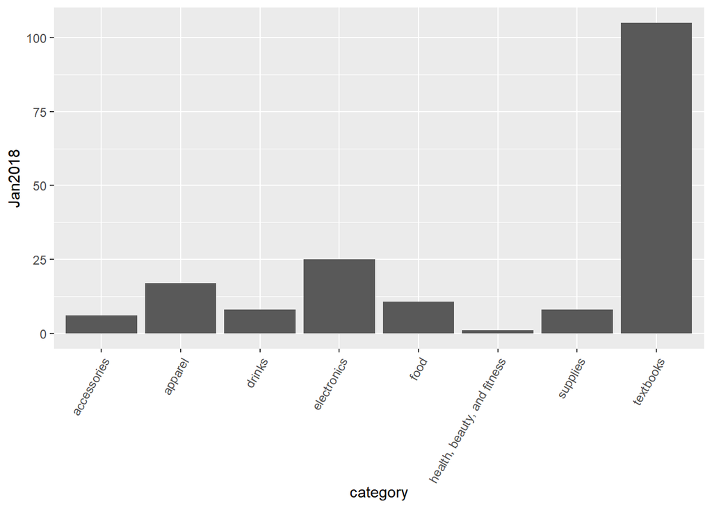

```r
ggplot(sales, aes(x = category, y = Jan2018)) + geom_bar(stat = "identity") + theme(axis.text.x = element_text(angle = 60, hjust = 1))
```

#### Here is an example of how we can use the data in the tables to create new tables with similar but different meanings.

#### I took the “sales” table and summed up the sales data for each month, which then went into a new table with 22 rows and two columns.

```r
salesMonths <- as.factor(c(colnames(sales)[2:23]))

salesSums <- c(sum(sales$Jan2018),sum(sales$Feb2018),sum(sales$Mar2018),
                 sum(sales$Apr2018),sum(sales$May2018),sum(sales$Jun2018),
                 sum(sales$Jul2018),sum(sales$Aug2018),sum(sales$Sep2018),
                 sum(sales$Oct2018),sum(sales$Nov2018),sum(sales$Dec2018),
                 sum(sales$Jan2019),sum(sales$Feb2019),sum(sales$Mar2019),
                 sum(sales$Apr2019),sum(sales$May2019),sum(sales$Jun2019),
                 sum(sales$Jul2019),sum(sales$Aug2019),sum(sales$Sep2019),
                 sum(sales$Oct2019))

totalSales <- tibble(salesMonths, salesSums)
head(totalSales)
```

| salesMonths | salesSums |
| --- | --- |
| Jan2018 | 180.60 |
| Feb2018 | 191.01 |
| Mar2018 | 75.50 |
| Apr2018 | 84.60 |
| May2018 | 117.80 |
| Jun2018 | 76.13 |

#### Now we can make a bar graph that shows the differences in total sales for all of the recorded months.

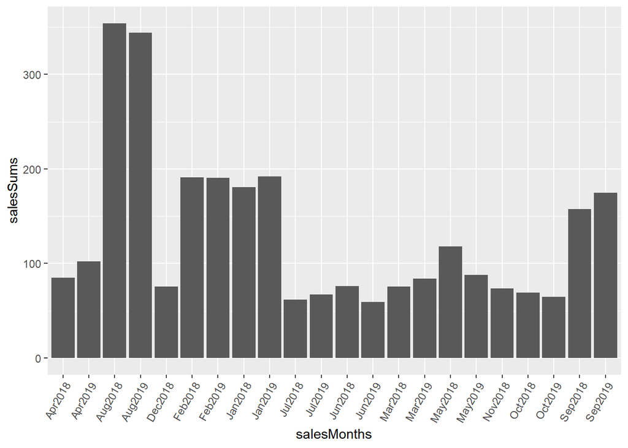

```r
ggplot(totalSales, aes(x = salesMonths, y = salesSums)) + geom_bar(stat = "identity") + theme(axis.text.x = element_text(angle = 60, hjust = 1))
```

#### We can see from this where the fluctuations occurred and where it was generally pretty low.

#### There is a problem with this, though. The data has automatically sorted itself alphabetically. This wouldn’t be an issue for a graph like the previous one where all of the categories are unrelated, but this data would be much more useful if you could see it in order by month. I haven’t figured out how to fix this yet, unfortunately.

#### The data provided could have many uses in the future. We could use it to find out what products are selling best at certain points in the year, and we can use it to plan on beefing up staff or only having minimal people working over certain months. The sales data from the register could help to identify specific customers’ shopping habits, and would provide a potential for creating a rewards program based on such. Hopefully I’ve done an okay job of demonstrating some basics of how we can read, sort, and manipulate data sets for some useful analyses.